# Relatório delegaçoes

#### 4.3.1.2 Parcela do MRE considerando apenas delegados vinculados ao governo

Pela política do governo brasileiro de credenciar representantes não-governamentais, esse tipo de participante representa um percentual muito alto das delegações brasileiras. Isso pode distorcer o % do MRE como dado para compreender sua importância no interior das delegações, dificultando a visualização da tendência. Vejamos, então, se os dados mudam de forma significativa quando olhamos apenas para os delegados vinculados ao governo federal.

```r
MRE_confgov <- deleg_evento %>% group_by(conf, ano, tipo_org_reduzido) %>%
  summarise(count = n()) %>%  ungroup %>%
  complete(tipo_org_reduzido, nesting(conf, ano),
           fill = list(count = 0)) %>%
  filter(! conf %in% eventosexcl) %>%
  filter(tipo_org_reduzido %in% c("Governo federal MRE",
                                  "Governo federal não-MRE")) %>%
  group_by(conf) %>%
  mutate(percentual = count/sum(count),
         deleg_size = sum(count)) %>% ungroup() %>%
  filter(!is.na(deleg_size)) %>% #retira deleg gov vazia
  left_join(select(eventos, c(conf, location, tema, tipo_evento))) %>%
  mutate(Local = if_else(str_detect(location, "Brazil"), "Brasil", "Fora do Brasil"),
         Tema = case_when (
           tema == "Clima" ~ "Clima",
           tema == "Grandes conferências ONU" ~ "Des. Sustentável",
           str_detect(tema, "Biodiversidade - CBD") ~ "Biodiversidade",
           tema != "Clima" & tema != "Grandes conferências ONU" & #tema != "Florestas" ~ "Outros"
             tema != "Biodiversidade - CBD" ~ "Outros"
         )
         )
```

Note-se que limitar a análise da delegação apenas ao governo não anula a relação verificada anteriormente, de declínio no percentual relativo do MRE à medida que aumenta o tamanho das delegações:

**Correlação para delegação completa**: -0.2391966 **Correlação para delegação considerando apenas governo federal**: -0.1791784

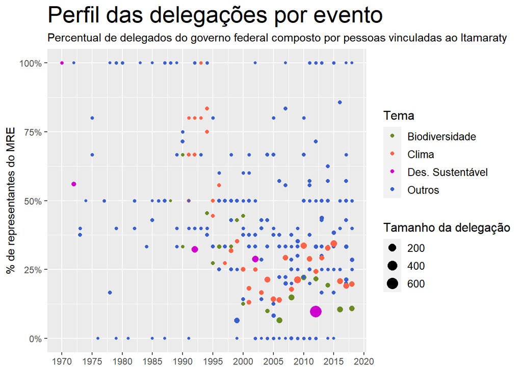

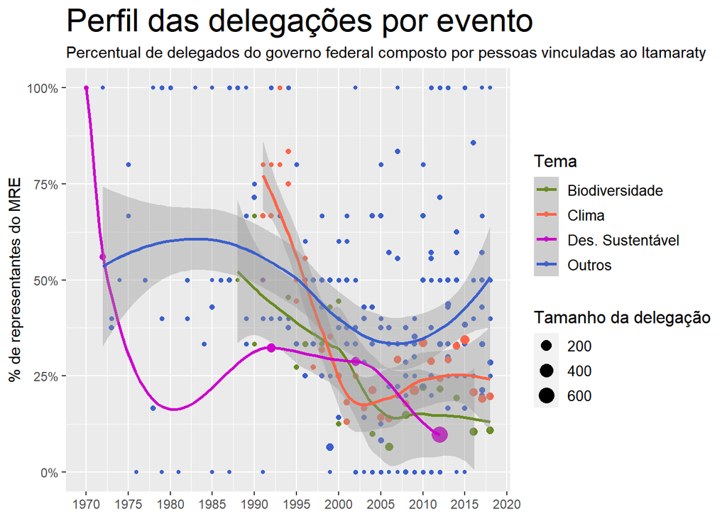

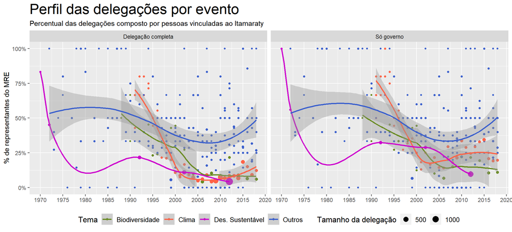

Vemos que há, na segunda metade dos anos 90, para todos os temas de eventos, um declínio do percentual do MRE relativo aos representantes governamentais nas delegações. Na década de 2000 há relativa estabilidade. Na década de 2010, porém, o MRE amplia seu espaço na área de clima e, em ainda maior grau, nos temas de menor destaque (“Outros”).

## 4.4 Transformações do perfil das organizações ao longo do tempo

Vimos acima o número de organizações distintas nas delegações e o percentual relativo do MRE na composição da delegação brasileira (completa ou só governo). Abaixo, aprofundamos a análise sobre a diversificação da delegação a partir das organizações participantes nos eventos. Agora, porém, não olhamos para o número de organizações distintas presentes, mas sim para parcela de grupos dessas organizações na delegação. Se antes o número de indivíduos vinculados às organizações era irrelevante, agora passa a ser um fator importante.

```r
freq_tipoorgs_tempo <- deleg_evento %>%
  group_by(ano, tipo_org_reduzido) %>%
  summarise(total = n()) %>% mutate(percentual = total / sum(total)) %>%
  ungroup() %>% # incluir contagem de observações nulas (freq = 0)
  complete(ano, tipo_org_reduzido, fill = list(total = 0, percentual = 0))


freq_tipoorgs_tempo$tipo_org_reduzido[freq_tipoorgs_tempo$tipo_org_reduzido == "Governos subnacionais (Executivo, Legislativo, Empresas Públicas ou Autarquias)"] <- "Governos subnacionais"



freq_tipoorgs_tempo$tipo_factor <- factor(freq_tipoorgs_tempo$tipo_org_reduzido,
                                      levels = c("Governo federal MRE",
                                                 "Governo federal não-MRE",
                                                 "Governos subnacionais",
                                                 "Legislativo federal",
                                                 "Sociedade civil, sindicatos, movimentos sociais", "Setor empresarial",
                                                 # "Sociedade civil e empresas"
                                                 "Órgãos de ensino e pesquisa",
                                                 "Outro",
                                                 "Não identificado"
                                                 ))
```

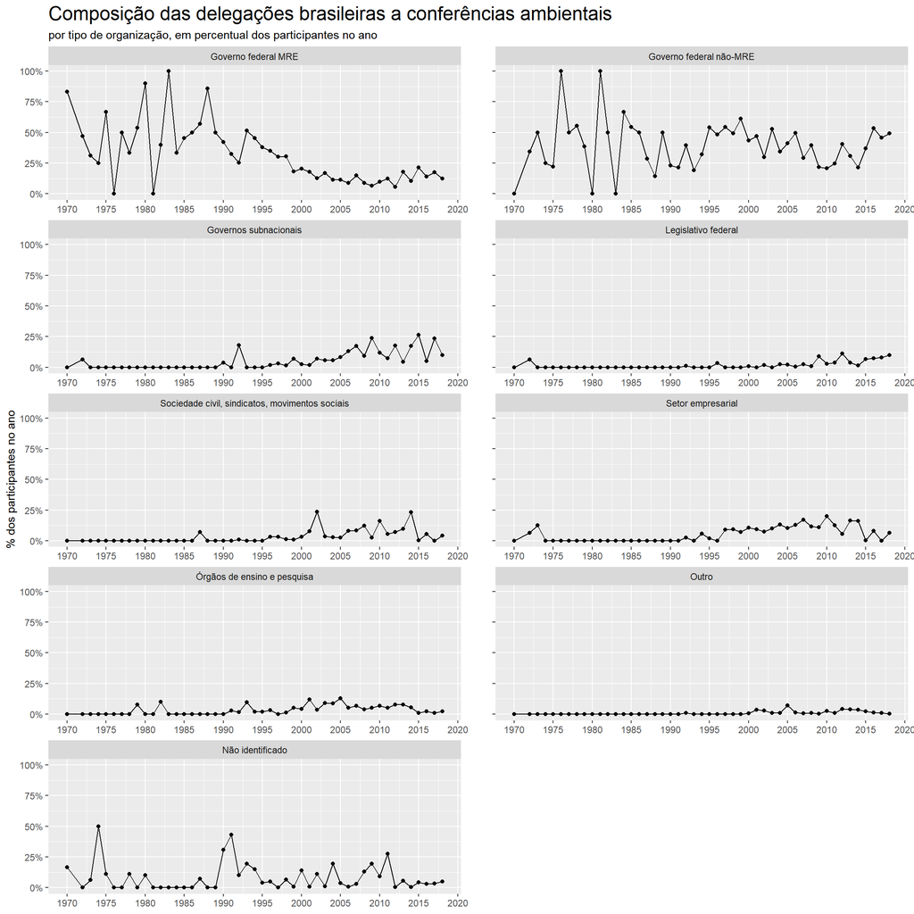

Agora a mesma figura, mas com menos orgaos

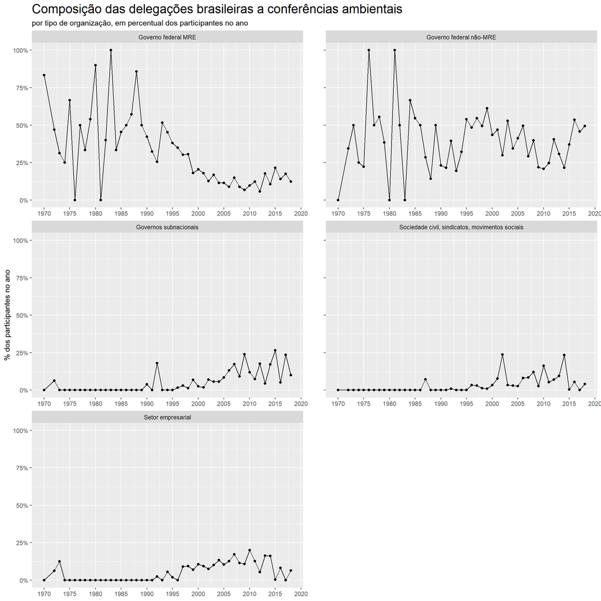

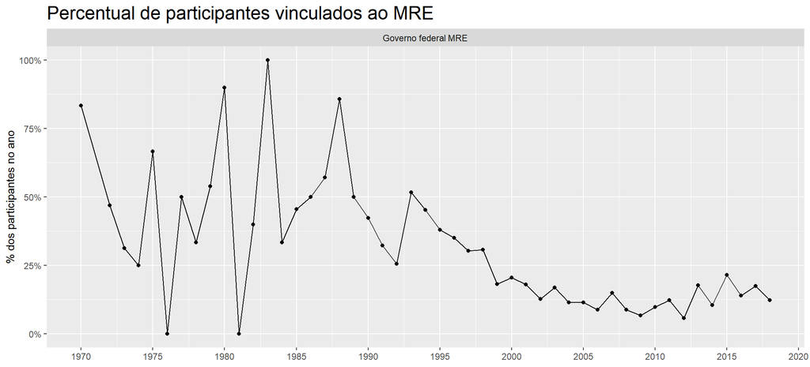

### 4.4.1 Comparação da composição por décadas

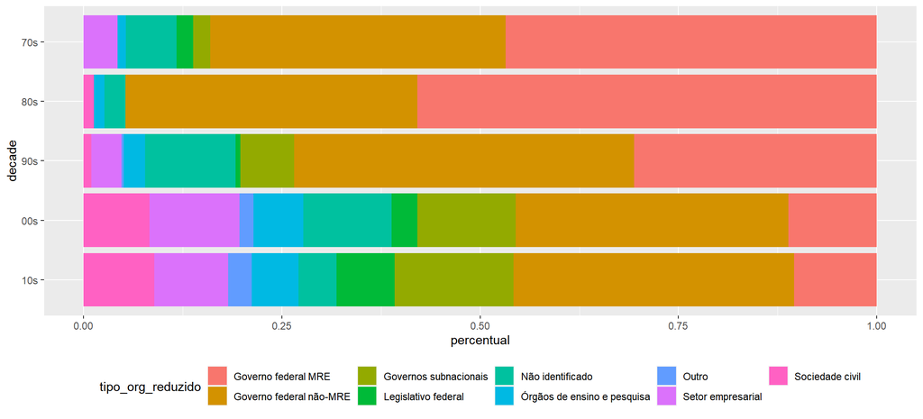

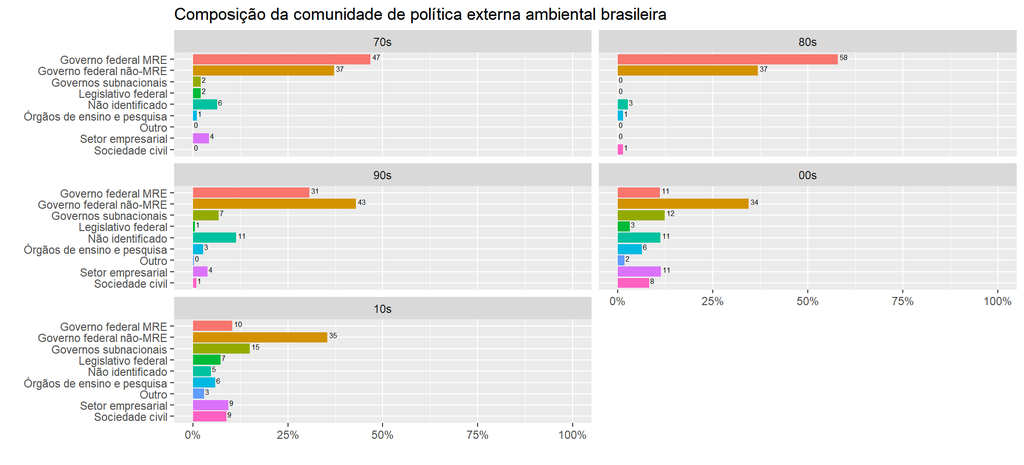

**Valores específicos para o texto:** % MRE em 1990:0.4230769

% MRE em 2000:0.204918

Média MRE nas décadas:

| decade | tipo_org_reduzido | total | percentual |
| --- | --- | --- | --- |
| 70s | Governo federal MRE | 44 | 0.4680851 |
| 80s | Governo federal MRE | 44 | 0.5789474 |
| 90s | Governo federal MRE | 217 | 0.3060649 |
| 00s | Governo federal MRE | 297 | 0.1112776 |
| 10s | Governo federal MRE | 439 | 0.1040778 |

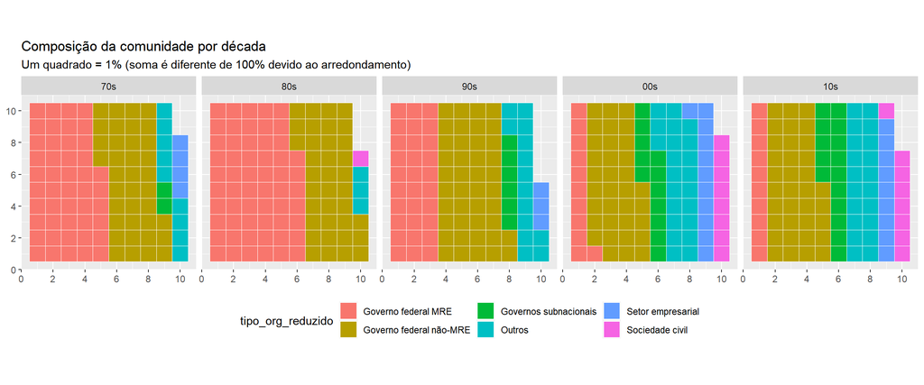

## 4.5 Evolução da participação de organizações específicas

```r
orgs_princ <- deleg_evento %>%
  mutate(org = case_when(
    org_limpo == "Ministério das Relações Exteriores" ~ "Ministério das Relações Exteriores",
    tipo_org == "Laboratórios, centros e institutos de pesquisa vinculados ao MCT" ~
      "Ministério da Ciência e Tecnologia",
    id_org_unica %in% c(23, 422, 553, 131) ~ "Ministério da Ciência e Tecnologia",
    id_org_unica %in% c(442, 324, 333, 555) ~ "Ministério do Meio Ambiente",
    # id_org_unica %in% c(326, 576, 441) ~ "Ministério do Meio Ambiente",
    id_org_unica %in% c(214, 421) ~ "Ministério da Agricultura, Pecuária e Abastecimento",
    id_org_unica %in% c(436, 137, 40, 124, 218) ~ "Ministério de Minas e Energia",
     id_org_unica %in% c(427, 699, 425, 97, 444, 556) ~ "Ministérios econômicos",
  )) %>%
  mutate(org = if_else(is.na(org), "Outro", org))
# No MMA: Foram incluídos SEMAM-PR (555), IBAMA (324), ICMBio (333). Não inclusão de IBDF (326), SFB (576), M Interior (441)
# No MCT: AEB (23), CIMGC (131), laboratórios nacionais e afins (por meio do tipo) - inclusive o INPE (352) e o INPA (351), SCT-PR (553)
# No MME: Comissão Nacional de Energia Nuclear (137), CNPE -  Conselho Nacional de Política Energética (140), ANEEL (40), CEPEL - Centro de Pesquisas de Energia Elétrica (124), Empresa de Pesquisa Energética (218). Não inclusão de Petrobrás (517), Eletrobrás (212), Furnas (303), Itaipu (400), Vale (155)
# Ministérios econômicos: MFaz (427), MEFP [collor] (699), M Econ [bols] (425), CADE (97), MPOG (444), SEPLAN-PR(556). Não inclusão: Casa da Moeda do Brasil (107), Banco Central (69), CVM (189), BNDES (86), Caixa (98), BB (71), BNB (72), etc
```

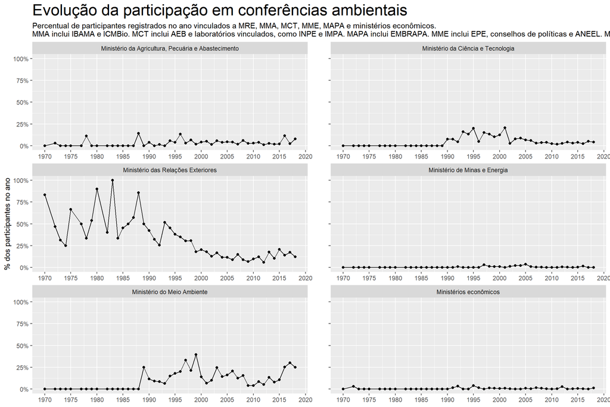

**Órgãos incluídos:** *No MMA: Foram incluídos SEMAM-PR (555), IBAMA (324), ICMBio (333). Não inclusão de IBDF (326), SFB (576), M Interior (441)* *No MCT: AEB (23), CIMGC (131), laboratórios nacionais e afins (por meio do tipo) - inclusive o INPE (352) e o INPA (351), SCT-PR (553)* *No MME: Comissão Nacional de Energia Nuclear (137), CNPE - Conselho Nacional de Política Energética (140), ANEEL (40), CEPEL - Centro de Pesquisas de Energia Elétrica (124), Empresa de Pesquisa Energética (218). Não inclusão de Petrobrás (517), Eletrobrás (212), Furnas (303), Itaipu (400), Vale (155)* *Ministérios econômicos: MFaz (427), MEFP [collor] (699), M Econ [bols] (425), CADE (97), MPOG (444), SEPLAN-PR(556). Não inclusão: Casa da Moeda do Brasil (107), Banco Central (69), CVM (189), BNDES (86), Caixa (98), BB (71), BNB (72), etc*

```r
freq_minist_tema <- orgs_princ %>%
  mutate(
    Tema = case_when (
           tema == "Clima" ~ "Clima",
           tema == "Biodiversidade - CBD" ~ "Biodiversidade",
           tema == "Grandes conferências ONU" ~ "Des. Sustentável",
           tema != "Clima" & tema != "Grandes conferências ONU" &
             tema != "Biodiversidade - CBD" ~ "Outros",
           )
    ) %>%
  group_by(ano, Tema, org) %>%
  summarise(total = n()) %>% mutate(percentual = total / sum(total)) %>%
  ungroup() %>%
  filter(org %in% c("Ministério das Relações Exteriores",
                    "Ministério do Meio Ambiente",
                    "Ministério da Ciência e Tecnologia",
                    "Ministério da Agricultura, Pecuária e Abastecimento",
                    "Ministério de Minas e Energia",
                    "Ministérios econômicos"

  )) %>%
  # incluir contagem de observações nulas (freq = 0)
  complete(ano, Tema, org,
           fill = list(total = 0, percentual = 0),
           explicit = FALSE)

temasano <- orgs_princ %>%
  mutate(
    Tema = case_when (
           tema == "Clima" ~ "Clima",
           tema == "Biodiversidade - CBD" ~ "Biodiversidade",
           tema == "Grandes conferências ONU" ~ "Des. Sustentável",
           tema != "Clima" & tema != "Grandes conferências ONU" &
             tema != "Biodiversidade - CBD" ~ "Outros",
           )
    ) %>% select(ano, Tema) %>% distinct() %>%
  mutate(anotema = paste0(ano, Tema))

freq_minist_tema <- freq_minist_tema %>%
  mutate(
  total = if_else(paste0(ano, Tema) %in% pull(temasano, anotema), total, NA ),
  percentual = if_else(paste0(ano, Tema) %in% pull(temasano, anotema), percentual, NA )
                            )
```

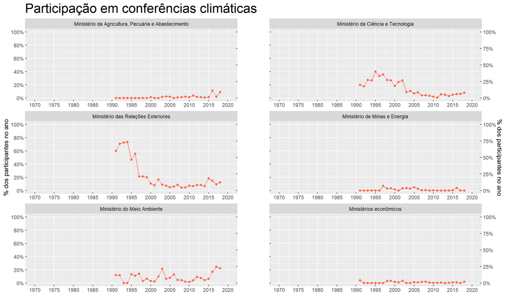

[mudar gráfico de biodiversidade: ao invés de tema, fazer só CBD. Essa mistura com os outros tratados, que têm outro perfil de participação, impede visualização de qualquer tendência.]

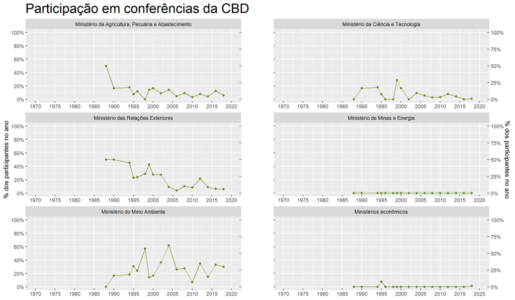

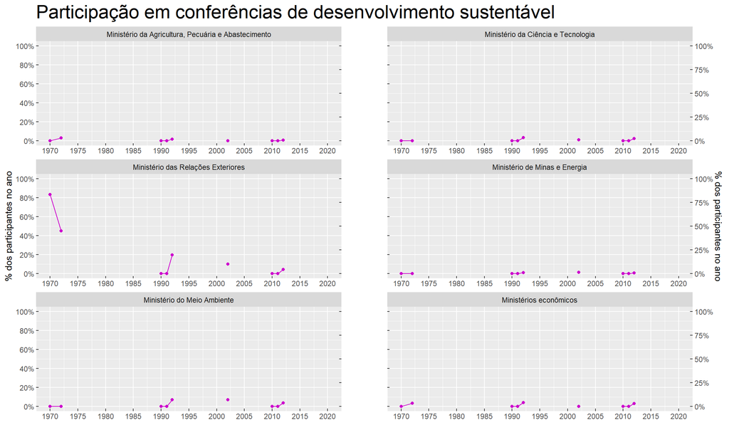

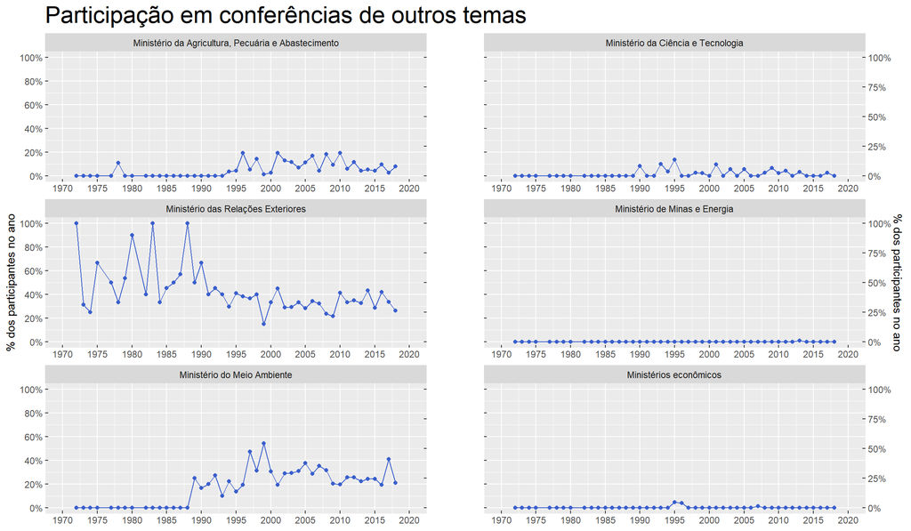